# Risk Factor Analysis

## Outcome Variable

**Outcome Variable:** ever_wasted

## Predictor Variables

**Intervention Variable:** exclfeed36

**Adjustment Set:**

- arm
- sex
- brthmon
- W_mage
- meducyrs
- feducyrs
- hhwealth_quart
- hfoodsec
- W_mhtcm
- W_mwtkg
- W_mbmi
- vagbrth
- W_gagebrth
- W_birthwt
- W_birthlen
- W_nrooms
- W_nchldlt5
- month
- W_parity
- impfloor
- impsan
- safeh20
- delta_W_mage
- delta_meducyrs
- delta_feducyrs
- delta_hhwealth_quart
- delta_hfoodsec
- delta_W_mhtcm
- delta_W_mwtkg
- delta_W_mbmi
- delta_vagbrth
- delta_W_gagebrth
- delta_W_birthwt
- delta_W_birthlen
- delta_W_nrooms
- delta_W_nchldlt5
- delta_month
- delta_W_parity
- delta_impfloor
- delta_impsan
- delta_safeh20

## Stratifying Variables

The analysis was stratified on these variable(s):

- agecat
- studyid
- country

## Data Summary

| agecat | studyid | country | exclfeed36 | ever_wasted | n_cell | n |
| --- | --- | --- | --- | --- | --- | --- |
| 0-24 months (no birth wast) | ki0047075b-MAL-ED | BANGLADESH | 1 | 0 | 27 | 251 |
| 0-24 months (no birth wast) | ki0047075b-MAL-ED | BANGLADESH | 1 | 1 | 6 | 251 |
| 0-24 months (no birth wast) | ki0047075b-MAL-ED | BANGLADESH | 0 | 0 | 167 | 251 |
| 0-24 months (no birth wast) | ki0047075b-MAL-ED | BANGLADESH | 0 | 1 | 51 | 251 |
| 0-24 months (no birth wast) | ki0047075b-MAL-ED | BRAZIL | 1 | 0 | 16 | 224 |
| 0-24 months (no birth wast) | ki0047075b-MAL-ED | BRAZIL | 1 | 1 | 0 | 224 |
| 0-24 months (no birth wast) | ki0047075b-MAL-ED | BRAZIL | 0 | 0 | 195 | 224 |
| 0-24 months (no birth wast) | ki0047075b-MAL-ED | BRAZIL | 0 | 1 | 13 | 224 |
| 0-24 months (no birth wast) | ki0047075b-MAL-ED | INDIA | 1 | 0 | 5 | 234 |
| 0-24 months (no birth wast) | ki0047075b-MAL-ED | INDIA | 1 | 1 | 5 | 234 |
| 0-24 months (no birth wast) | ki0047075b-MAL-ED | INDIA | 0 | 0 | 140 | 234 |
| 0-24 months (no birth wast) | ki0047075b-MAL-ED | INDIA | 0 | 1 | 84 | 234 |
| 0-24 months (no birth wast) | ki0047075b-MAL-ED | NEPAL | 1 | 0 | 4 | 235 |
| 0-24 months (no birth wast) | ki0047075b-MAL-ED | NEPAL | 1 | 1 | 0 | 235 |
| 0-24 months (no birth wast) | ki0047075b-MAL-ED | NEPAL | 0 | 0 | 185 | 235 |
| 0-24 months (no birth wast) | ki0047075b-MAL-ED | NEPAL | 0 | 1 | 46 | 235 |
| 0-24 months (no birth wast) | ki0047075b-MAL-ED | PERU | 1 | 0 | 10 | 286 |
| 0-24 months (no birth wast) | ki0047075b-MAL-ED | PERU | 1 | 1 | 0 | 286 |
| 0-24 months (no birth wast) | ki0047075b-MAL-ED | PERU | 0 | 0 | 255 | 286 |
| 0-24 months (no birth wast) | ki0047075b-MAL-ED | PERU | 0 | 1 | 21 | 286 |
| 0-24 months (no birth wast) | ki0047075b-MAL-ED | SOUTH AFRICA | 1 | 0 | 4 | 276 |
| 0-24 months (no birth wast) | ki0047075b-MAL-ED | SOUTH AFRICA | 1 | 1 | 0 | 276 |
| 0-24 months (no birth wast) | ki0047075b-MAL-ED | SOUTH AFRICA | 0 | 0 | 227 | 276 |
| 0-24 months (no birth wast) | ki0047075b-MAL-ED | SOUTH AFRICA | 0 | 1 | 45 | 276 |
| 0-24 months (no birth wast) | ki0047075b-MAL-ED | TANZANIA, UNITED REPUBLIC OF | 1 | 0 | 5 | 250 |
| 0-24 months (no birth wast) | ki0047075b-MAL-ED | TANZANIA, UNITED REPUBLIC OF | 1 | 1 | 0 | 250 |
| 0-24 months (no birth wast) | ki0047075b-MAL-ED | TANZANIA, UNITED REPUBLIC OF | 0 | 0 | 212 | 250 |
| 0-24 months (no birth wast) | ki0047075b-MAL-ED | TANZANIA, UNITED REPUBLIC OF | 0 | 1 | 33 | 250 |
| 0-24 months (no birth wast) | ki1000108-CMC-V-BCS-2002 | INDIA | 1 | 0 | 7 | 9 |
| 0-24 months (no birth wast) | ki1000108-CMC-V-BCS-2002 | INDIA | 1 | 1 | 2 | 9 |

[output cut: 174 more lines]

The following strata were considered:

- agecat: 0-24 months (no birth wast), studyid: ki0047075b-MAL-ED, country: BANGLADESH
- agecat: 0-24 months (no birth wast), studyid: ki0047075b-MAL-ED, country: BRAZIL
- agecat: 0-24 months (no birth wast), studyid: ki0047075b-MAL-ED, country: INDIA
- agecat: 0-24 months (no birth wast), studyid: ki0047075b-MAL-ED, country: NEPAL
- agecat: 0-24 months (no birth wast), studyid: ki0047075b-MAL-ED, country: PERU
- agecat: 0-24 months (no birth wast), studyid: ki0047075b-MAL-ED, country: SOUTH AFRICA
- agecat: 0-24 months (no birth wast), studyid: ki0047075b-MAL-ED, country: TANZANIA, UNITED REPUBLIC OF
- agecat: 0-24 months (no birth wast), studyid: ki1000108-CMC-V-BCS-2002, country: INDIA
- agecat: 0-24 months (no birth wast), studyid: ki1000108-IRC, country: INDIA
- agecat: 0-24 months (no birth wast), studyid: ki1000109-EE, country: PAKISTAN
- agecat: 0-24 months (no birth wast), studyid: ki1000304b-SAS-FoodSuppl, country: INDIA
- agecat: 0-24 months (no birth wast), studyid: ki1017093b-PROVIDE, country: BANGLADESH
- agecat: 0-24 months (no birth wast), studyid: ki1101329-Keneba, country: GAMBIA
- agecat: 0-24 months (no birth wast), studyid: ki1113344-GMS-Nepal, country: NEPAL
- agecat: 0-24 months (no birth wast), studyid: ki1148112-LCNI-5, country: MALAWI
- agecat: 0-24 months (no birth wast), studyid: kiGH5241-JiVitA-3, country: BANGLADESH
- agecat: 0-24 months (no birth wast), studyid: kiGH5241-JiVitA-4, country: BANGLADESH
- agecat: 0-6 months (no birth wast), studyid: ki0047075b-MAL-ED, country: BANGLADESH
- agecat: 0-6 months (no birth wast), studyid: ki0047075b-MAL-ED, country: BRAZIL
- agecat: 0-6 months (no birth wast), studyid: ki0047075b-MAL-ED, country: INDIA
- agecat: 0-6 months (no birth wast), studyid: ki0047075b-MAL-ED, country: NEPAL
- agecat: 0-6 months (no birth wast), studyid: ki0047075b-MAL-ED, country: PERU
- agecat: 0-6 months (no birth wast), studyid: ki0047075b-MAL-ED, country: SOUTH AFRICA
- agecat: 0-6 months (no birth wast), studyid: ki0047075b-MAL-ED, country: TANZANIA, UNITED REPUBLIC OF
- agecat: 0-6 months (no birth wast), studyid: ki1000108-CMC-V-BCS-2002, country: INDIA
- agecat: 0-6 months (no birth wast), studyid: ki1000108-IRC, country: INDIA
- agecat: 0-6 months (no birth wast), studyid: ki1000109-EE, country: PAKISTAN
- agecat: 0-6 months (no birth wast), studyid: ki1000304b-SAS-FoodSuppl, country: INDIA
- agecat: 0-6 months (no birth wast), studyid: ki1017093b-PROVIDE, country: BANGLADESH
- agecat: 0-6 months (no birth wast), studyid: ki1101329-Keneba, country: GAMBIA
- agecat: 0-6 months (no birth wast), studyid: ki1113344-GMS-Nepal, country: NEPAL
- agecat: 0-6 months (no birth wast), studyid: ki1148112-LCNI-5, country: MALAWI
- agecat: 0-6 months (no birth wast), studyid: kiGH5241-JiVitA-3, country: BANGLADESH
- agecat: 0-6 months (no birth wast), studyid: kiGH5241-JiVitA-4, country: BANGLADESH
- agecat: 6-24 months, studyid: ki0047075b-MAL-ED, country: BANGLADESH
- agecat: 6-24 months, studyid: ki0047075b-MAL-ED, country: BRAZIL
- agecat: 6-24 months, studyid: ki0047075b-MAL-ED, country: INDIA
- agecat: 6-24 months, studyid: ki0047075b-MAL-ED, country: NEPAL
- agecat: 6-24 months, studyid: ki0047075b-MAL-ED, country: PERU
- agecat: 6-24 months, studyid: ki0047075b-MAL-ED, country: SOUTH AFRICA
- agecat: 6-24 months, studyid: ki0047075b-MAL-ED, country: TANZANIA, UNITED REPUBLIC OF
- agecat: 6-24 months, studyid: ki1000108-CMC-V-BCS-2002, country: INDIA
- agecat: 6-24 months, studyid: ki1000108-IRC, country: INDIA
- agecat: 6-24 months, studyid: ki1000109-EE, country: PAKISTAN
- agecat: 6-24 months, studyid: ki1000304b-SAS-FoodSuppl, country: INDIA
- agecat: 6-24 months, studyid: ki1017093b-PROVIDE, country: BANGLADESH
- agecat: 6-24 months, studyid: ki1101329-Keneba, country: GAMBIA
- agecat: 6-24 months, studyid: ki1113344-GMS-Nepal, country: NEPAL
- agecat: 6-24 months, studyid: ki1148112-LCNI-5, country: MALAWI
- agecat: 6-24 months, studyid: kiGH5241-JiVitA-3, country: BANGLADESH
- agecat: 6-24 months, studyid: kiGH5241-JiVitA-4, country: BANGLADESH

### Dropped Strata

Some strata were dropped due to rare outcomes:

- agecat: 0-24 months (no birth wast), studyid: ki0047075b-MAL-ED, country: BRAZIL
- agecat: 0-24 months (no birth wast), studyid: ki0047075b-MAL-ED, country: NEPAL
- agecat: 0-24 months (no birth wast), studyid: ki0047075b-MAL-ED, country: PERU
- agecat: 0-24 months (no birth wast), studyid: ki0047075b-MAL-ED, country: SOUTH AFRICA
- agecat: 0-24 months (no birth wast), studyid: ki0047075b-MAL-ED, country: TANZANIA, UNITED REPUBLIC OF
- agecat: 0-24 months (no birth wast), studyid: ki1000108-CMC-V-BCS-2002, country: INDIA
- agecat: 0-24 months (no birth wast), studyid: ki1000108-IRC, country: INDIA
- agecat: 0-24 months (no birth wast), studyid: ki1000109-EE, country: PAKISTAN
- agecat: 0-24 months (no birth wast), studyid: ki1000304b-SAS-FoodSuppl, country: INDIA
- agecat: 0-6 months (no birth wast), studyid: ki0047075b-MAL-ED, country: BANGLADESH
- agecat: 0-6 months (no birth wast), studyid: ki0047075b-MAL-ED, country: BRAZIL
- agecat: 0-6 months (no birth wast), studyid: ki0047075b-MAL-ED, country: INDIA
- agecat: 0-6 months (no birth wast), studyid: ki0047075b-MAL-ED, country: NEPAL
- agecat: 0-6 months (no birth wast), studyid: ki0047075b-MAL-ED, country: PERU
- agecat: 0-6 months (no birth wast), studyid: ki0047075b-MAL-ED, country: SOUTH AFRICA
- agecat: 0-6 months (no birth wast), studyid: ki0047075b-MAL-ED, country: TANZANIA, UNITED REPUBLIC OF
- agecat: 0-6 months (no birth wast), studyid: ki1000108-CMC-V-BCS-2002, country: INDIA
- agecat: 0-6 months (no birth wast), studyid: ki1000108-IRC, country: INDIA
- agecat: 0-6 months (no birth wast), studyid: ki1000109-EE, country: PAKISTAN
- agecat: 0-6 months (no birth wast), studyid: ki1000304b-SAS-FoodSuppl, country: INDIA
- agecat: 0-6 months (no birth wast), studyid: ki1148112-LCNI-5, country: MALAWI
- agecat: 6-24 months, studyid: ki0047075b-MAL-ED, country: BRAZIL
- agecat: 6-24 months, studyid: ki0047075b-MAL-ED, country: INDIA
- agecat: 6-24 months, studyid: ki0047075b-MAL-ED, country: NEPAL
- agecat: 6-24 months, studyid: ki0047075b-MAL-ED, country: PERU
- agecat: 6-24 months, studyid: ki0047075b-MAL-ED, country: SOUTH AFRICA
- agecat: 6-24 months, studyid: ki0047075b-MAL-ED, country: TANZANIA, UNITED REPUBLIC OF
- agecat: 6-24 months, studyid: ki1000108-CMC-V-BCS-2002, country: INDIA
- agecat: 6-24 months, studyid: ki1000108-IRC, country: INDIA
- agecat: 6-24 months, studyid: ki1000109-EE, country: PAKISTAN
- agecat: 6-24 months, studyid: ki1000304b-SAS-FoodSuppl, country: INDIA

## Methods Detail

We’re interested in the causal parameters $E[Y_a]$ for all values of $a \in \mathcal{A}$. These parameters represent the mean outcome if, possibly contrary to fact, we intervened to set all units to have $A=a$. Under the randomization and positivity assumptions, these are identified by the statistical parameters $\psi_a=E_W[E_{Y|A,W}(Y|A=a,W)]$. In addition, we’re interested in the mean of $Y$, $E[Y]$ under no intervention (the observed mean). We will estimate these parameters by using SuperLearner to fit the relevant likelihood factors – $E_{Y|A,W}(Y|A=a,W)$ and $p(A=a|W)$, and then updating our likelihood fit using a joint TMLE.

For unadjusted analyses ($W=\{\}$), initial likelihoods were estimated using Lrnr_glm to estimate the simple $E(Y|A)$ and Lrnr_mean to estimate $p(A)$. For adjusted analyses, a small library containing Lrnr_glmnet, Lrnr_xgboost, and Lrnr_mean was used.

Having estimated these parameters, we will then use the delta method to estimate relative risks and attributable risks relative to a prespecified baseline level of $A$.

# Results Detail

## Results Plots

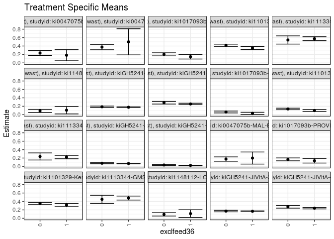

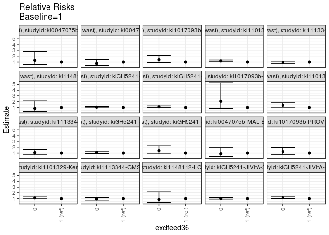

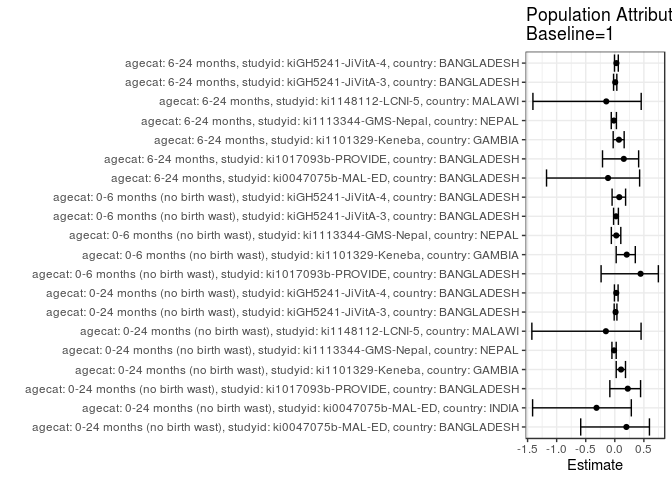

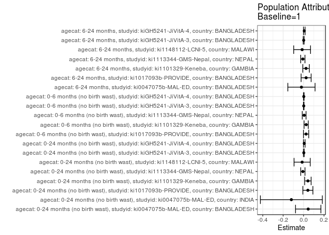

## Results Table

### Parameter: TSM

| agecat | studyid | country | intervention_level | baseline_level | estimate | ci_lower | ci_upper |
| --- | --- | --- | --- | --- | --- | --- | --- |
| 0-24 months (no birth wast) | ki0047075b-MAL-ED | BANGLADESH | 1 | NA | 0.1818182 | 0.0499617 | 0.3136747 |
| 0-24 months (no birth wast) | ki0047075b-MAL-ED | BANGLADESH | 0 | NA | 0.2339450 | 0.1776365 | 0.2902534 |
| 0-24 months (no birth wast) | ki0047075b-MAL-ED | INDIA | 1 | NA | 0.5000000 | 0.1894382 | 0.8105618 |
| 0-24 months (no birth wast) | ki0047075b-MAL-ED | INDIA | 0 | NA | 0.3750000 | 0.3114655 | 0.4385345 |
| 0-24 months (no birth wast) | ki1017093b-PROVIDE | BANGLADESH | 1 | NA | 0.1468707 | 0.0917141 | 0.2020272 |
| 0-24 months (no birth wast) | ki1017093b-PROVIDE | BANGLADESH | 0 | NA | 0.2032335 | 0.1669582 | 0.2395087 |
| 0-24 months (no birth wast) | ki1101329-Keneba | GAMBIA | 1 | NA | 0.3525624 | 0.3149469 | 0.3901780 |
| 0-24 months (no birth wast) | ki1101329-Keneba | GAMBIA | 0 | NA | 0.4180974 | 0.3919069 | 0.4442880 |
| 0-24 months (no birth wast) | ki1113344-GMS-Nepal | NEPAL | 1 | NA | 0.5736177 | 0.5265597 | 0.6206756 |
| 0-24 months (no birth wast) | ki1113344-GMS-Nepal | NEPAL | 0 | NA | 0.5432675 | 0.4456544 | 0.6408806 |
| 0-24 months (no birth wast) | ki1148112-LCNI-5 | MALAWI | 1 | NA | 0.1063830 | 0.0180722 | 0.1946938 |
| 0-24 months (no birth wast) | ki1148112-LCNI-5 | MALAWI | 0 | NA | 0.0892857 | 0.0518739 | 0.1266975 |
| 0-24 months (no birth wast) | kiGH5241-JiVitA-3 | BANGLADESH | 1 | NA | 0.1771303 | 0.1687157 | 0.1855450 |
| 0-24 months (no birth wast) | kiGH5241-JiVitA-3 | BANGLADESH | 0 | NA | 0.1875391 | 0.1705967 | 0.2044815 |
| 0-24 months (no birth wast) | kiGH5241-JiVitA-4 | BANGLADESH | 1 | NA | 0.2545598 | 0.2372542 | 0.2718655 |
| 0-24 months (no birth wast) | kiGH5241-JiVitA-4 | BANGLADESH | 0 | NA | 0.2844226 | 0.2528800 | 0.3159653 |
| 0-6 months (no birth wast) | ki1017093b-PROVIDE | BANGLADESH | 1 | NA | 0.0308642 | 0.0042107 | 0.0575177 |
| 0-6 months (no birth wast) | ki1017093b-PROVIDE | BANGLADESH | 0 | NA | 0.0639659 | 0.0418030 | 0.0861288 |
| 0-6 months (no birth wast) | ki1101329-Keneba | GAMBIA | 1 | NA | 0.0985572 | 0.0750044 | 0.1221099 |
| 0-6 months (no birth wast) | ki1101329-Keneba | GAMBIA | 0 | NA | 0.1361535 | 0.1178440 | 0.1544631 |
| 0-6 months (no birth wast) | ki1113344-GMS-Nepal | NEPAL | 1 | NA | 0.2236167 | 0.1831912 | 0.2640423 |
| 0-6 months (no birth wast) | ki1113344-GMS-Nepal | NEPAL | 0 | NA | 0.2380546 | 0.1538388 | 0.3222705 |
| 0-6 months (no birth wast) | kiGH5241-JiVitA-3 | BANGLADESH | 1 | NA | 0.0703858 | 0.0646783 | 0.0760933 |
| 0-6 months (no birth wast) | kiGH5241-JiVitA-3 | BANGLADESH | 0 | NA | 0.0772755 | 0.0650100 | 0.0895409 |
| 0-6 months (no birth wast) | kiGH5241-JiVitA-4 | BANGLADESH | 1 | NA | 0.0254052 | 0.0192171 | 0.0315933 |
| 0-6 months (no birth wast) | kiGH5241-JiVitA-4 | BANGLADESH | 0 | NA | 0.0353226 | 0.0217801 | 0.0488651 |
| 6-24 months | ki0047075b-MAL-ED | BANGLADESH | 1 | NA | 0.2000000 | 0.0565653 | 0.3434347 |
| 6-24 months | ki0047075b-MAL-ED | BANGLADESH | 0 | NA | 0.1761905 | 0.1245548 | 0.2278261 |
| 6-24 months | ki1017093b-PROVIDE | BANGLADESH | 1 | NA | 0.1365303 | 0.0810365 | 0.1920241 |
| 6-24 months | ki1017093b-PROVIDE | BANGLADESH | 0 | NA | 0.1687284 | 0.1344426 | 0.2030141 |
| 6-24 months | ki1101329-Keneba | GAMBIA | 1 | NA | 0.3140892 | 0.2761321 | 0.3520462 |
| 6-24 months | ki1101329-Keneba | GAMBIA | 0 | NA | 0.3506108 | 0.3250430 | 0.3761786 |
| 6-24 months | ki1113344-GMS-Nepal | NEPAL | 1 | NA | 0.4806693 | 0.4332382 | 0.5281005 |
| 6-24 months | ki1113344-GMS-Nepal | NEPAL | 0 | NA | 0.4501101 | 0.3537229 | 0.5464973 |
| 6-24 months | ki1148112-LCNI-5 | MALAWI | 1 | NA | 0.1111111 | 0.0191112 | 0.2031111 |
| 6-24 months | ki1148112-LCNI-5 | MALAWI | 0 | NA | 0.0938967 | 0.0546489 | 0.1331445 |
| 6-24 months | kiGH5241-JiVitA-3 | BANGLADESH | 1 | NA | 0.1663609 | 0.1567216 | 0.1760002 |
| 6-24 months | kiGH5241-JiVitA-3 | BANGLADESH | 0 | NA | 0.1713489 | 0.1532521 | 0.1894457 |
| 6-24 months | kiGH5241-JiVitA-4 | BANGLADESH | 1 | NA | 0.2399408 | 0.2230416 | 0.2568401 |
| 6-24 months | kiGH5241-JiVitA-4 | BANGLADESH | 0 | NA | 0.2726918 | 0.2411353 | 0.3042482 |

### Parameter: E(Y)

| agecat | studyid | country | intervention_level | baseline_level | estimate | ci_lower | ci_upper |
| --- | --- | --- | --- | --- | --- | --- | --- |
| 0-24 months (no birth wast) | ki0047075b-MAL-ED | BANGLADESH | NA | NA | 0.2270916 | 0.1751587 | 0.2790245 |
| 0-24 months (no birth wast) | ki0047075b-MAL-ED | INDIA | NA | NA | 0.3803419 | 0.3180067 | 0.4426771 |
| 0-24 months (no birth wast) | ki1017093b-PROVIDE | BANGLADESH | NA | NA | 0.1889764 | 0.1585028 | 0.2194500 |
| 0-24 months (no birth wast) | ki1101329-Keneba | GAMBIA | NA | NA | 0.3951368 | 0.3735650 | 0.4167086 |
| 0-24 months (no birth wast) | ki1113344-GMS-Nepal | NEPAL | NA | NA | 0.5667939 | 0.5243264 | 0.6092614 |
| 0-24 months (no birth wast) | ki1148112-LCNI-5 | MALAWI | NA | NA | 0.0922509 | 0.0577338 | 0.1267680 |
| 0-24 months (no birth wast) | kiGH5241-JiVitA-3 | BANGLADESH | NA | NA | 0.1795035 | 0.1720409 | 0.1869661 |
| 0-24 months (no birth wast) | kiGH5241-JiVitA-4 | BANGLADESH | NA | NA | 0.2612415 | 0.2461119 | 0.2763711 |
| 0-6 months (no birth wast) | ki1017093b-PROVIDE | BANGLADESH | NA | NA | 0.0554675 | 0.0375942 | 0.0733408 |
| 0-6 months (no birth wast) | ki1101329-Keneba | GAMBIA | NA | NA | 0.1239796 | 0.1093860 | 0.1385732 |
| 0-6 months (no birth wast) | ki1113344-GMS-Nepal | NEPAL | NA | NA | 0.2294118 | 0.1928853 | 0.2659383 |
| 0-6 months (no birth wast) | kiGH5241-JiVitA-3 | BANGLADESH | NA | NA | 0.0719217 | 0.0666549 | 0.0771884 |
| 0-6 months (no birth wast) | kiGH5241-JiVitA-4 | BANGLADESH | NA | NA | 0.0275209 | 0.0219532 | 0.0330885 |
| 6-24 months | ki0047075b-MAL-ED | BANGLADESH | NA | NA | 0.1791667 | 0.1305478 | 0.2277856 |
| 6-24 months | ki1017093b-PROVIDE | BANGLADESH | NA | NA | 0.1615008 | 0.1323459 | 0.1906557 |
| 6-24 months | ki1101329-Keneba | GAMBIA | NA | NA | 0.3382353 | 0.3169789 | 0.3594917 |
| 6-24 months | ki1113344-GMS-Nepal | NEPAL | NA | NA | 0.4733840 | 0.4306748 | 0.5160933 |
| 6-24 months | ki1148112-LCNI-5 | MALAWI | NA | NA | 0.0968992 | 0.0607324 | 0.1330660 |
| 6-24 months | kiGH5241-JiVitA-3 | BANGLADESH | NA | NA | 0.1675737 | 0.1590914 | 0.1760560 |
| 6-24 months | kiGH5241-JiVitA-4 | BANGLADESH | NA | NA | 0.2468327 | 0.2318250 | 0.2618404 |

### Parameter: RR

| agecat | studyid | country | intervention_level | baseline_level | estimate | ci_lower | ci_upper |
| --- | --- | --- | --- | --- | --- | --- | --- |
| 0-24 months (no birth wast) | ki0047075b-MAL-ED | BANGLADESH | 1 | 1 | 1.0000000 | 1.0000000 | 1.000000 |
| 0-24 months (no birth wast) | ki0047075b-MAL-ED | BANGLADESH | 0 | 1 | 1.2866972 | 0.5992775 | 2.762643 |
| 0-24 months (no birth wast) | ki0047075b-MAL-ED | INDIA | 1 | 1 | 1.0000000 | 1.0000000 | 1.000000 |
| 0-24 months (no birth wast) | ki0047075b-MAL-ED | INDIA | 0 | 1 | 0.7500000 | 0.3939629 | 1.427799 |
| 0-24 months (no birth wast) | ki1017093b-PROVIDE | BANGLADESH | 1 | 1 | 1.0000000 | 1.0000000 | 1.000000 |
| 0-24 months (no birth wast) | ki1017093b-PROVIDE | BANGLADESH | 0 | 1 | 1.3837580 | 0.9134023 | 2.096323 |
| 0-24 months (no birth wast) | ki1101329-Keneba | GAMBIA | 1 | 1 | 1.0000000 | 1.0000000 | 1.000000 |
| 0-24 months (no birth wast) | ki1101329-Keneba | GAMBIA | 0 | 1 | 1.1858819 | 1.0483893 | 1.341406 |
| 0-24 months (no birth wast) | ki1113344-GMS-Nepal | NEPAL | 1 | 1 | 1.0000000 | 1.0000000 | 1.000000 |
| 0-24 months (no birth wast) | ki1113344-GMS-Nepal | NEPAL | 0 | 1 | 0.9470899 | 0.7783259 | 1.152447 |
| 0-24 months (no birth wast) | ki1148112-LCNI-5 | MALAWI | 1 | 1 | 1.0000000 | 1.0000000 | 1.000000 |
| 0-24 months (no birth wast) | ki1148112-LCNI-5 | MALAWI | 0 | 1 | 0.8392857 | 0.3311837 | 2.126918 |
| 0-24 months (no birth wast) | kiGH5241-JiVitA-3 | BANGLADESH | 1 | 1 | 1.0000000 | 1.0000000 | 1.000000 |
| 0-24 months (no birth wast) | kiGH5241-JiVitA-3 | BANGLADESH | 0 | 1 | 1.0587631 | 0.9550850 | 1.173696 |
| 0-24 months (no birth wast) | kiGH5241-JiVitA-4 | BANGLADESH | 1 | 1 | 1.0000000 | 1.0000000 | 1.000000 |
| 0-24 months (no birth wast) | kiGH5241-JiVitA-4 | BANGLADESH | 0 | 1 | 1.1173115 | 0.9822395 | 1.270958 |
| 0-6 months (no birth wast) | ki1017093b-PROVIDE | BANGLADESH | 1 | 1 | 1.0000000 | 1.0000000 | 1.000000 |
| 0-6 months (no birth wast) | ki1017093b-PROVIDE | BANGLADESH | 0 | 1 | 2.0724947 | 0.8173110 | 5.255324 |
| 0-6 months (no birth wast) | ki1101329-Keneba | GAMBIA | 1 | 1 | 1.0000000 | 1.0000000 | 1.000000 |
| 0-6 months (no birth wast) | ki1101329-Keneba | GAMBIA | 0 | 1 | 1.3814678 | 1.0509196 | 1.815984 |
| 0-6 months (no birth wast) | ki1113344-GMS-Nepal | NEPAL | 1 | 1 | 1.0000000 | 1.0000000 | 1.000000 |
| 0-6 months (no birth wast) | ki1113344-GMS-Nepal | NEPAL | 0 | 1 | 1.0645654 | 0.7154104 | 1.584125 |
| 0-6 months (no birth wast) | kiGH5241-JiVitA-3 | BANGLADESH | 1 | 1 | 1.0000000 | 1.0000000 | 1.000000 |
| 0-6 months (no birth wast) | kiGH5241-JiVitA-3 | BANGLADESH | 0 | 1 | 1.0978845 | 0.9201610 | 1.309934 |
| 0-6 months (no birth wast) | kiGH5241-JiVitA-4 | BANGLADESH | 1 | 1 | 1.0000000 | 1.0000000 | 1.000000 |
| 0-6 months (no birth wast) | kiGH5241-JiVitA-4 | BANGLADESH | 0 | 1 | 1.3903694 | 0.8729907 | 2.214373 |
| 6-24 months | ki0047075b-MAL-ED | BANGLADESH | 1 | 1 | 1.0000000 | 1.0000000 | 1.000000 |
| 6-24 months | ki0047075b-MAL-ED | BANGLADESH | 0 | 1 | 0.8809524 | 0.4059626 | 1.911696 |
| 6-24 months | ki1017093b-PROVIDE | BANGLADESH | 1 | 1 | 1.0000000 | 1.0000000 | 1.000000 |
| 6-24 months | ki1017093b-PROVIDE | BANGLADESH | 0 | 1 | 1.2358308 | 0.7842893 | 1.947340 |
| 6-24 months | ki1101329-Keneba | GAMBIA | 1 | 1 | 1.0000000 | 1.0000000 | 1.000000 |
| 6-24 months | ki1101329-Keneba | GAMBIA | 0 | 1 | 1.1162778 | 0.9697156 | 1.284991 |
| 6-24 months | ki1113344-GMS-Nepal | NEPAL | 1 | 1 | 1.0000000 | 1.0000000 | 1.000000 |
| 6-24 months | ki1113344-GMS-Nepal | NEPAL | 0 | 1 | 0.9364236 | 0.7404855 | 1.184208 |
| 6-24 months | ki1148112-LCNI-5 | MALAWI | 1 | 1 | 1.0000000 | 1.0000000 | 1.000000 |
| 6-24 months | ki1148112-LCNI-5 | MALAWI | 0 | 1 | 0.8450704 | 0.3342527 | 2.136539 |
| 6-24 months | kiGH5241-JiVitA-3 | BANGLADESH | 1 | 1 | 1.0000000 | 1.0000000 | 1.000000 |
| 6-24 months | kiGH5241-JiVitA-3 | BANGLADESH | 0 | 1 | 1.0299830 | 0.9129162 | 1.162062 |
| 6-24 months | kiGH5241-JiVitA-4 | BANGLADESH | 1 | 1 | 1.0000000 | 1.0000000 | 1.000000 |
| 6-24 months | kiGH5241-JiVitA-4 | BANGLADESH | 0 | 1 | 1.1364958 | 0.9946888 | 1.298520 |

### Parameter: PAR

| agecat | studyid | country | intervention_level | baseline_level | estimate | ci_lower | ci_upper |
| --- | --- | --- | --- | --- | --- | --- | --- |
| 0-24 months (no birth wast) | ki0047075b-MAL-ED | BANGLADESH | 1 | NA | 0.0452735 | -0.0792718 | 0.1698187 |
| 0-24 months (no birth wast) | ki0047075b-MAL-ED | INDIA | 1 | NA | -0.1196581 | -0.4231229 | 0.1838066 |
| 0-24 months (no birth wast) | ki1017093b-PROVIDE | BANGLADESH | 1 | NA | 0.0421057 | -0.0071693 | 0.0913807 |
| 0-24 months (no birth wast) | ki1101329-Keneba | GAMBIA | 1 | NA | 0.0425743 | 0.0110969 | 0.0740517 |
| 0-24 months (no birth wast) | ki1113344-GMS-Nepal | NEPAL | 1 | NA | -0.0068238 | -0.0276262 | 0.0139787 |
| 0-24 months (no birth wast) | ki1148112-LCNI-5 | MALAWI | 1 | NA | -0.0141321 | -0.0934107 | 0.0651466 |
| 0-24 months (no birth wast) | kiGH5241-JiVitA-3 | BANGLADESH | 1 | NA | 0.0023732 | -0.0018709 | 0.0066172 |
| 0-24 months (no birth wast) | kiGH5241-JiVitA-4 | BANGLADESH | 1 | NA | 0.0066817 | -0.0015314 | 0.0148947 |
| 0-6 months (no birth wast) | ki1017093b-PROVIDE | BANGLADESH | 1 | NA | 0.0246033 | -0.0011861 | 0.0503927 |
| 0-6 months (no birth wast) | ki1101329-Keneba | GAMBIA | 1 | NA | 0.0254224 | 0.0050385 | 0.0458064 |
| 0-6 months (no birth wast) | ki1113344-GMS-Nepal | NEPAL | 1 | NA | 0.0057950 | -0.0128477 | 0.0244378 |
| 0-6 months (no birth wast) | kiGH5241-JiVitA-3 | BANGLADESH | 1 | NA | 0.0015359 | -0.0014490 | 0.0045207 |
| 0-6 months (no birth wast) | kiGH5241-JiVitA-4 | BANGLADESH | 1 | NA | 0.0021157 | -0.0010799 | 0.0053112 |
| 6-24 months | ki0047075b-MAL-ED | BANGLADESH | 1 | NA | -0.0208333 | -0.1542272 | 0.1125605 |
| 6-24 months | ki1017093b-PROVIDE | BANGLADESH | 1 | NA | 0.0249705 | -0.0242294 | 0.0741704 |
| 6-24 months | ki1101329-Keneba | GAMBIA | 1 | NA | 0.0241461 | -0.0077377 | 0.0560299 |
| 6-24 months | ki1113344-GMS-Nepal | NEPAL | 1 | NA | -0.0072853 | -0.0282384 | 0.0136678 |
| 6-24 months | ki1148112-LCNI-5 | MALAWI | 1 | NA | -0.0142119 | -0.0967920 | 0.0683682 |
| 6-24 months | kiGH5241-JiVitA-3 | BANGLADESH | 1 | NA | 0.0012128 | -0.0034954 | 0.0059210 |
| 6-24 months | kiGH5241-JiVitA-4 | BANGLADESH | 1 | NA | 0.0068918 | -0.0011624 | 0.0149461 |

### Parameter: PAF

| agecat | studyid | country | intervention_level | baseline_level | estimate | ci_lower | ci_upper |
| --- | --- | --- | --- | --- | --- | --- | --- |
| 0-24 months (no birth wast) | ki0047075b-MAL-ED | BANGLADESH | 1 | NA | 0.1993620 | -0.5862897 | 0.5958991 |
| 0-24 months (no birth wast) | ki0047075b-MAL-ED | INDIA | 1 | NA | -0.3146067 | -1.4139018 | 0.2840674 |
| 0-24 months (no birth wast) | ki1017093b-PROVIDE | BANGLADESH | 1 | NA | 0.2228094 | -0.0852070 | 0.4434009 |
| 0-24 months (no birth wast) | ki1101329-Keneba | GAMBIA | 1 | NA | 0.1077458 | 0.0243772 | 0.1839904 |
| 0-24 months (no birth wast) | ki1113344-GMS-Nepal | NEPAL | 1 | NA | -0.0120392 | -0.0494379 | 0.0240266 |
| 0-24 months (no birth wast) | ki1148112-LCNI-5 | MALAWI | 1 | NA | -0.1531915 | -1.4265796 | 0.4519650 |
| 0-24 months (no birth wast) | kiGH5241-JiVitA-3 | BANGLADESH | 1 | NA | 0.0132207 | -0.0106891 | 0.0365648 |
| 0-24 months (no birth wast) | kiGH5241-JiVitA-4 | BANGLADESH | 1 | NA | 0.0255766 | -0.0064300 | 0.0565652 |
| 0-6 months (no birth wast) | ki1017093b-PROVIDE | BANGLADESH | 1 | NA | 0.4435626 | -0.2356792 | 0.7494313 |
| 0-6 months (no birth wast) | ki1101329-Keneba | GAMBIA | 1 | NA | 0.2050535 | 0.0239071 | 0.3525821 |
| 0-6 months (no birth wast) | ki1113344-GMS-Nepal | NEPAL | 1 | NA | 0.0252604 | -0.0594419 | 0.1031909 |
| 0-6 months (no birth wast) | kiGH5241-JiVitA-3 | BANGLADESH | 1 | NA | 0.0213545 | -0.0208588 | 0.0618222 |
| 0-6 months (no birth wast) | kiGH5241-JiVitA-4 | BANGLADESH | 1 | NA | 0.0768749 | -0.0465915 | 0.1857761 |
| 6-24 months | ki0047075b-MAL-ED | BANGLADESH | 1 | NA | -0.1162791 | -1.1742051 | 0.4268807 |
| 6-24 months | ki1017093b-PROVIDE | BANGLADESH | 1 | NA | 0.1546154 | -0.2113167 | 0.4100014 |
| 6-24 months | ki1101329-Keneba | GAMBIA | 1 | NA | 0.0713885 | -0.0278441 | 0.1610408 |
| 6-24 months | ki1113344-GMS-Nepal | NEPAL | 1 | NA | -0.0153898 | -0.0606646 | 0.0279525 |
| 6-24 months | ki1148112-LCNI-5 | MALAWI | 1 | NA | -0.1466667 | -1.4083049 | 0.4540374 |
| 6-24 months | kiGH5241-JiVitA-3 | BANGLADESH | 1 | NA | 0.0072375 | -0.0212571 | 0.0349369 |
| 6-24 months | kiGH5241-JiVitA-4 | BANGLADESH | 1 | NA | 0.0279211 | -0.0052759 | 0.0600218 |